# Assigning ASVs with DADA2

Roger Calvas

2025-03-11

# Goals

1. Infer an error model for in the filtered sequences, separately on forward and reverse reads.
2. Assign ASVs on both forward and reverse reads separately by applying the error model.
3. Merge forward and reverse ASVs into “contiguous ASVs”.
4. Generate the first draft of ASV count table.
5. Quality Trimming of ASV lengths.
6. Remove chimeras.
7. Assign Taxonomy with Silva Database.
8. Write out relevant files: `asv_table`, `asvs_fasta`, `tax_table`, and `sample_data`.

## Input

1. Filtered fastq files generated from `01_QualityTrimming.Rmd`.
2. Sample Name vector.

## Output

1. ASV Count Table: `asv_table` (with and without sequence names)
2. ASV fasta file: `asvs_fasta` for building a phylogenetic tree at a later step.
3. Taxonomy Table `tax_table`
4. Sample Information: `sample_data` track the reads lots throughout DADA2 workflow.

# Set up the Environment

```r
# Set the seed for reproducibility
set.seed(39809473)

# Let's make a parameter to set the number of threads
n_threads = 20
```

#Timing of the script

```r
# What time did we start running this script?
start_time <- Sys.time()
```

## Load Packages

```r
# Efficient package loading with pacman
pacman::p_load(tidyverse, devtools, dada2,
               patchwork, DT, install = FALSE)
```

## Load Filtered Fastq Files

```r
# Place filtered seq files into a variable
filtered_fastqs_path <- "data/01_DADA2/02_filtered_fastqs"

# Intuition check:
filtered_fastqs_path
```

```
## [1] "data/01_DADA2/02_filtered_fastqs"
```

```r
# Create Forward vector
filtered_forward_reads <-
  list.files(filtered_fastqs_path, pattern = "R1_filtered.fastq.gz",
             full.names = TRUE)
# Check
filtered_forward_reads[1:5]
```

```
## [1] "data/01_DADA2/02_filtered_fastqs/SRR6443836_R1_filtered.fastq.gz"
## [2] "data/01_DADA2/02_filtered_fastqs/SRR6443837_R1_filtered.fastq.gz"
## [3] "data/01_DADA2/02_filtered_fastqs/SRR6443839_R1_filtered.fastq.gz"
## [4] "data/01_DADA2/02_filtered_fastqs/SRR6443840_R1_filtered.fastq.gz"
## [5] "data/01_DADA2/02_filtered_fastqs/SRR6443844_R1_filtered.fastq.gz"
```

```r
# Reverse vector
filtered_reverse_reads <-
    list.files(filtered_fastqs_path, pattern = "R2_filtered.fastq.gz",
             full.names = TRUE)

# Check
filtered_reverse_reads[1:5]
```

```
## [1] "data/01_DADA2/02_filtered_fastqs/SRR6443836_R2_filtered.fastq.gz"
## [2] "data/01_DADA2/02_filtered_fastqs/SRR6443837_R2_filtered.fastq.gz"
## [3] "data/01_DADA2/02_filtered_fastqs/SRR6443839_R2_filtered.fastq.gz"
## [4] "data/01_DADA2/02_filtered_fastqs/SRR6443840_R2_filtered.fastq.gz"
## [5] "data/01_DADA2/02_filtered_fastqs/SRR6443844_R2_filtered.fastq.gz"
```

## Sample Names

```r
# Create vector of sample names from the filenames
sample_names <- sapply(strsplit(basename(filtered_forward_reads), "_"), `[`, 1)

# Intuition Check
head(sample_names)
```

```
## [1] "SRR6443836" "SRR6443837" "SRR6443839" "SRR6443840" "SRR6443844"
## [6] "SRR6443845"
```

## Learn the Errors

```r
# Forward Reads
error_forward_reads <-
  learnErrors(filtered_forward_reads, multithread = n_threads)
```

```
## 100826003 total bases in 417720 reads from 19 samples will be used for learning the error rates.
```

```r
# Forward Error Plot
forward_error_plot <-
  plotErrors(error_forward_reads, nominalQ = TRUE) +
  labs(title = "Forward Reads: Error Model")

# Reverse Reads
error_reverse_reads <-
  learnErrors(filtered_reverse_reads, multithread = n_threads)
```

```
## 110699247 total bases in 536177 reads from 23 samples will be used for learning the error rates.
```

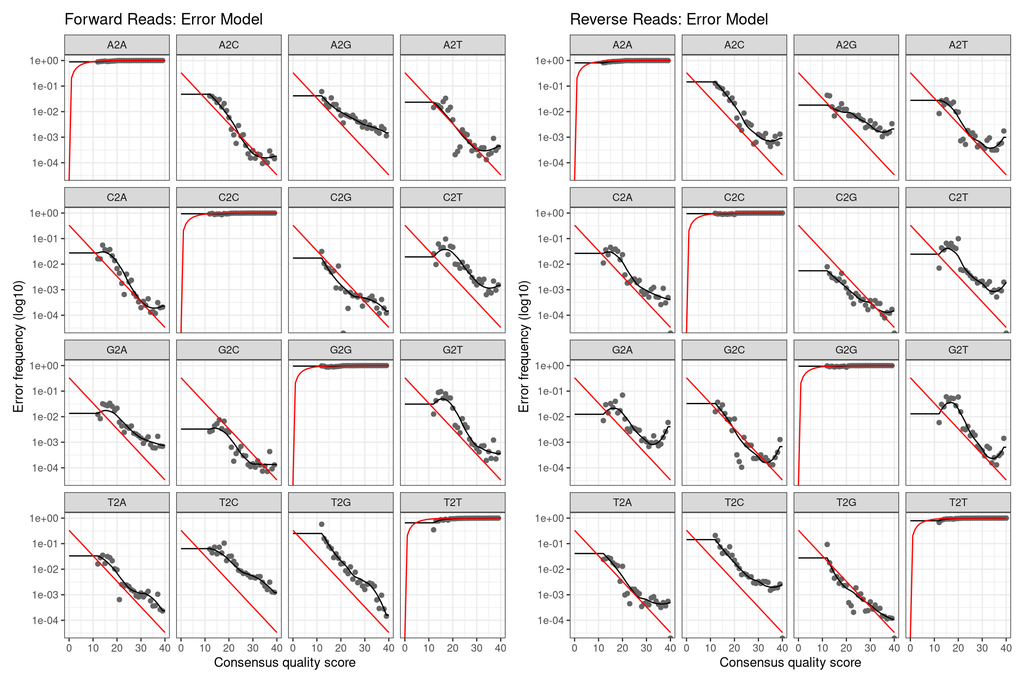

```r
# Reverse Error Plot
reverse_error_plot <-
  plotErrors(error_reverse_reads, nominalQ = TRUE) +
  labs(title = "Reverse Reads: Error Model")

# Look at the plots together
forward_error_plot + reverse_error_plot
```

#Infer ASVs

```r
# Infer ASVs on the forward sequences
dada_forward <-
  dada(filtered_forward_reads,
       err = error_forward_reads,
       multithread = n_threads)
```

```
## Sample 1 - 22469 reads in 4180 unique sequences.
## Sample 2 - 10509 reads in 4069 unique sequences.
## Sample 3 - 31717 reads in 6965 unique sequences.
## Sample 4 - 22998 reads in 6091 unique sequences.
## Sample 5 - 11559 reads in 2688 unique sequences.
## Sample 6 - 17080 reads in 4999 unique sequences.
## Sample 7 - 12209 reads in 4537 unique sequences.
## Sample 8 - 19912 reads in 6648 unique sequences.
## Sample 9 - 23328 reads in 7923 unique sequences.
## Sample 10 - 32631 reads in 5682 unique sequences.
## Sample 11 - 25453 reads in 7910 unique sequences.
## Sample 12 - 7466 reads in 2036 unique sequences.
## Sample 13 - 15924 reads in 5483 unique sequences.
## Sample 14 - 21465 reads in 6502 unique sequences.
## Sample 15 - 25154 reads in 8492 unique sequences.
## Sample 16 - 29018 reads in 8557 unique sequences.
## Sample 17 - 28202 reads in 9220 unique sequences.
## Sample 18 - 18193 reads in 3963 unique sequences.
## Sample 19 - 42433 reads in 15202 unique sequences.
## Sample 20 - 22350 reads in 5561 unique sequences.
## Sample 21 - 16312 reads in 4923 unique sequences.
## Sample 22 - 28055 reads in 5243 unique sequences.
## Sample 23 - 51740 reads in 18162 unique sequences.
## Sample 24 - 15198 reads in 2153 unique sequences.
## Sample 25 - 21175 reads in 3723 unique sequences.
## Sample 26 - 33742 reads in 11444 unique sequences.
## Sample 27 - 21046 reads in 4301 unique sequences.
## Sample 28 - 18756 reads in 7493 unique sequences.
## Sample 29 - 75745 reads in 18890 unique sequences.
## Sample 30 - 43949 reads in 12288 unique sequences.
## Sample 31 - 15221 reads in 3077 unique sequences.
## Sample 32 - 15084 reads in 5368 unique sequences.
## Sample 33 - 51443 reads in 16616 unique sequences.
## Sample 34 - 14650 reads in 4820 unique sequences.
## Sample 35 - 15688 reads in 3547 unique sequences.
## Sample 36 - 20730 reads in 4913 unique sequences.
## Sample 37 - 24221 reads in 6493 unique sequences.
## Sample 38 - 15838 reads in 3111 unique sequences.
## Sample 39 - 42773 reads in 12840 unique sequences.
## Sample 40 - 13368 reads in 4934 unique sequences.
```

[output cut: 312 more lines]

```
## Sample 353 - 28045 reads in 9925 unique sequences.
## Sample 354 - 28410 reads in 5392 unique sequences.
## Sample 355 - 28386 reads in 4512 unique sequences.
## Sample 356 - 17781 reads in 2327 unique sequences.
## Sample 357 - 16733 reads in 6807 unique sequences.
## Sample 358 - 13959 reads in 3002 unique sequences.
## Sample 359 - 16722 reads in 5637 unique sequences.
## Sample 360 - 19689 reads in 3049 unique sequences.
## Sample 361 - 28046 reads in 8609 unique sequences.
## Sample 362 - 22135 reads in 3768 unique sequences.
## Sample 363 - 44283 reads in 13120 unique sequences.
## Sample 364 - 25277 reads in 4148 unique sequences.
## Sample 365 - 20390 reads in 7239 unique sequences.
## Sample 366 - 19341 reads in 4035 unique sequences.
## Sample 367 - 15317 reads in 5717 unique sequences.
```

```r
# Take a look at the data
# What type of data structure is it?
typeof(dada_forward) # It's a list
```

```
## [1] "list"
```

```r
length(dada_forward) # How big is it? One per sample!
```

```
## [1] 367
```

```r
# What doees it look like for each sample?
dada_forward$`SRR6445038_R1_filtered.fastq.gz`
```

```
## dada-class: object describing DADA2 denoising results
## 114 sequence variants were inferred from 5717 input unique sequences.
## Key parameters: OMEGA_A = 1e-40, OMEGA_C = 1e-40, BAND_SIZE = 16
```

```r
# Reverse ASVs
dada_reverse <-
  dada(filtered_reverse_reads,
       err = error_reverse_reads ,
       multithread = n_threads)
```

```
## Sample 1 - 22469 reads in 4643 unique sequences.
## Sample 2 - 10509 reads in 5270 unique sequences.
## Sample 3 - 31717 reads in 6966 unique sequences.
## Sample 4 - 22998 reads in 6276 unique sequences.
## Sample 5 - 11559 reads in 2714 unique sequences.
## Sample 6 - 17080 reads in 6507 unique sequences.
## Sample 7 - 12209 reads in 5704 unique sequences.
## Sample 8 - 19912 reads in 8148 unique sequences.
## Sample 9 - 23328 reads in 10481 unique sequences.
## Sample 10 - 32631 reads in 5706 unique sequences.
## Sample 11 - 25453 reads in 13532 unique sequences.
## Sample 12 - 7466 reads in 2862 unique sequences.
## Sample 13 - 15924 reads in 8348 unique sequences.
## Sample 14 - 21465 reads in 9791 unique sequences.
## Sample 15 - 25154 reads in 10692 unique sequences.
## Sample 16 - 29018 reads in 12708 unique sequences.
## Sample 17 - 28202 reads in 11758 unique sequences.
## Sample 18 - 18193 reads in 4169 unique sequences.
## Sample 19 - 42433 reads in 23554 unique sequences.
## Sample 20 - 22350 reads in 5271 unique sequences.
## Sample 21 - 16312 reads in 6551 unique sequences.
## Sample 22 - 28055 reads in 5104 unique sequences.
## Sample 23 - 51740 reads in 23910 unique sequences.
## Sample 24 - 15198 reads in 2335 unique sequences.
## Sample 25 - 21175 reads in 3786 unique sequences.
## Sample 26 - 33742 reads in 14333 unique sequences.
## Sample 27 - 21046 reads in 4202 unique sequences.
## Sample 28 - 18756 reads in 9703 unique sequences.
## Sample 29 - 75745 reads in 27136 unique sequences.
## Sample 30 - 43949 reads in 21444 unique sequences.
## Sample 31 - 15221 reads in 3192 unique sequences.
## Sample 32 - 15084 reads in 7516 unique sequences.
## Sample 33 - 51443 reads in 29729 unique sequences.
## Sample 34 - 14650 reads in 6556 unique sequences.
## Sample 35 - 15688 reads in 3678 unique sequences.
## Sample 36 - 20730 reads in 6111 unique sequences.
## Sample 37 - 24221 reads in 10832 unique sequences.
## Sample 38 - 15838 reads in 3700 unique sequences.
## Sample 39 - 42773 reads in 18896 unique sequences.
## Sample 40 - 13368 reads in 6144 unique sequences.
```

[output cut: 312 more lines]

```
## Sample 353 - 28045 reads in 12754 unique sequences.
## Sample 354 - 28410 reads in 5067 unique sequences.
## Sample 355 - 28386 reads in 4633 unique sequences.
## Sample 356 - 17781 reads in 2655 unique sequences.
## Sample 357 - 16733 reads in 9002 unique sequences.
## Sample 358 - 13959 reads in 3165 unique sequences.
## Sample 359 - 16722 reads in 9427 unique sequences.
## Sample 360 - 19689 reads in 3105 unique sequences.
## Sample 361 - 28046 reads in 13903 unique sequences.
## Sample 362 - 22135 reads in 3748 unique sequences.
## Sample 363 - 44283 reads in 22229 unique sequences.
## Sample 364 - 25277 reads in 4822 unique sequences.
## Sample 365 - 20390 reads in 9337 unique sequences.
## Sample 366 - 19341 reads in 4083 unique sequences.
## Sample 367 - 15317 reads in 7651 unique sequences.
```

```r
# Check data
dada_reverse[30]
```

```
## $SRR6443941_R2_filtered.fastq.gz
## dada-class: object describing DADA2 denoising results
## 115 sequence variants were inferred from 21444 input unique sequences.
## Key parameters: OMEGA_A = 1e-40, OMEGA_C = 1e-40, BAND_SIZE = 16
```

# Merge Forward and Reverse ASVs

```r
merged_ASVs <-
  mergePairs(dada_forward, filtered_forward_reads,
             dada_reverse, filtered_reverse_reads,
             verbose = TRUE)
```

```
## 22196 paired-reads (in 138 unique pairings) successfully merged out of 22252 (in 171 pairings) input.
```

```
## 9854 paired-reads (in 86 unique pairings) successfully merged out of 10219 (in 169 pairings) input.
```

```
## 30538 paired-reads (in 269 unique pairings) successfully merged out of 31103 (in 377 pairings) input.
```

```
## 22752 paired-reads (in 32 unique pairings) successfully merged out of 22914 (in 48 pairings) input.
```

```
## 11182 paired-reads (in 135 unique pairings) successfully merged out of 11302 (in 171 pairings) input.
```

```
## 16843 paired-reads (in 33 unique pairings) successfully merged out of 17003 (in 74 pairings) input.
```

```
## 11808 paired-reads (in 67 unique pairings) successfully merged out of 11995 (in 128 pairings) input.
```

```
## 19444 paired-reads (in 80 unique pairings) successfully merged out of 19705 (in 176 pairings) input.
```

```
## 21846 paired-reads (in 140 unique pairings) successfully merged out of 22718 (in 302 pairings) input.
```

```
## 31701 paired-reads (in 180 unique pairings) successfully merged out of 32361 (in 249 pairings) input.
```

```
## 24053 paired-reads (in 97 unique pairings) successfully merged out of 25121 (in 277 pairings) input.
```

```
## 7330 paired-reads (in 26 unique pairings) successfully merged out of 7376 (in 41 pairings) input.
```

```
## 14854 paired-reads (in 112 unique pairings) successfully merged out of 15525 (in 211 pairings) input.
```

```
## 21014 paired-reads (in 68 unique pairings) successfully merged out of 21319 (in 147 pairings) input.
```

```
## 24497 paired-reads (in 85 unique pairings) successfully merged out of 24984 (in 189 pairings) input.
```

```
## 28191 paired-reads (in 60 unique pairings) successfully merged out of 28775 (in 131 pairings) input.
```

```
## 27291 paired-reads (in 86 unique pairings) successfully merged out of 27948 (in 216 pairings) input.
```

```
## 17598 paired-reads (in 173 unique pairings) successfully merged out of 17827 (in 221 pairings) input.
```

```
## 38710 paired-reads (in 192 unique pairings) successfully merged out of 41503 (in 621 pairings) input.
```

```
## 20575 paired-reads (in 252 unique pairings) successfully merged out of 21590 (in 467 pairings) input.
```

```
## 15799 paired-reads (in 69 unique pairings) successfully merged out of 16166 (in 158 pairings) input.
```

```
## 27203 paired-reads (in 129 unique pairings) successfully merged out of 27748 (in 197 pairings) input.
```

```
## 47394 paired-reads (in 271 unique pairings) successfully merged out of 50464 (in 1056 pairings) input.
```

```
## 14928 paired-reads (in 89 unique pairings) successfully merged out of 15034 (in 114 pairings) input.
```

```
## 20834 paired-reads (in 119 unique pairings) successfully merged out of 21015 (in 154 pairings) input.
```

```
## 32692 paired-reads (in 139 unique pairings) successfully merged out of 33361 (in 294 pairings) input.
```

```
## 20552 paired-reads (in 141 unique pairings) successfully merged out of 20897 (in 187 pairings) input.
```

```
## 17871 paired-reads (in 109 unique pairings) successfully merged out of 18390 (in 251 pairings) input.
```

```
## 74481 paired-reads (in 83 unique pairings) successfully merged out of 75450 (in 182 pairings) input.
```

```
## 42006 paired-reads (in 119 unique pairings) successfully merged out of 43563 (in 390 pairings) input.
```

```
## 14861 paired-reads (in 142 unique pairings) successfully merged out of 14970 (in 179 pairings) input.
```

```
## 14492 paired-reads (in 74 unique pairings) successfully merged out of 14938 (in 165 pairings) input.
```

```
## 47906 paired-reads (in 171 unique pairings) successfully merged out of 50512 (in 619 pairings) input.
```

```
## 14359 paired-reads (in 59 unique pairings) successfully merged out of 14585 (in 105 pairings) input.
```

```
## 15339 paired-reads (in 151 unique pairings) successfully merged out of 15451 (in 193 pairings) input.
```

```
## 20380 paired-reads (in 50 unique pairings) successfully merged out of 20639 (in 82 pairings) input.
```

```
## 23474 paired-reads (in 81 unique pairings) successfully merged out of 24057 (in 172 pairings) input.
```

```
## 15515 paired-reads (in 111 unique pairings) successfully merged out of 15638 (in 161 pairings) input.
```

```
## 41567 paired-reads (in 123 unique pairings) successfully merged out of 42487 (in 265 pairings) input.
```

```
## 12622 paired-reads (in 86 unique pairings) successfully merged out of 13113 (in 189 pairings) input.
```

```
## 19134 paired-reads (in 94 unique pairings) successfully merged out of 19395 (in 172 pairings) input.
```

```
## 19801 paired-reads (in 79 unique pairings) successfully merged out of 19952 (in 119 pairings) input.
```

```
## 15776 paired-reads (in 91 unique pairings) successfully merged out of 16162 (in 170 pairings) input.
```

```
## 22172 paired-reads (in 209 unique pairings) successfully merged out of 22416 (in 274 pairings) input.
```

```
## 15540 paired-reads (in 184 unique pairings) successfully merged out of 15780 (in 240 pairings) input.
```

```
## 28289 paired-reads (in 82 unique pairings) successfully merged out of 29067 (in 190 pairings) input.
```

```
## 25212 paired-reads (in 93 unique pairings) successfully merged out of 26152 (in 270 pairings) input.
```

```
## 23156 paired-reads (in 196 unique pairings) successfully merged out of 24324 (in 358 pairings) input.
```

```
## 17421 paired-reads (in 121 unique pairings) successfully merged out of 18044 (in 282 pairings) input.
```

```
## 17710 paired-reads (in 121 unique pairings) successfully merged out of 17785 (in 162 pairings) input.
```

```
## 18529 paired-reads (in 120 unique pairings) successfully merged out of 18833 (in 178 pairings) input.
```

```
## 36419 paired-reads (in 178 unique pairings) successfully merged out of 37473 (in 433 pairings) input.
```

```
## 20885 paired-reads (in 51 unique pairings) successfully merged out of 21121 (in 84 pairings) input.
```

```
## 15116 paired-reads (in 73 unique pairings) successfully merged out of 15415 (in 146 pairings) input.
```

```
## 24752 paired-reads (in 141 unique pairings) successfully merged out of 25428 (in 308 pairings) input.
```

```
## 29366 paired-reads (in 227 unique pairings) successfully merged out of 30009 (in 358 pairings) input.
```

```
## 18395 paired-reads (in 107 unique pairings) successfully merged out of 18774 (in 164 pairings) input.
```

```
## 22106 paired-reads (in 53 unique pairings) successfully merged out of 22356 (in 71 pairings) input.
```

```
## 15795 paired-reads (in 112 unique pairings) successfully merged out of 15938 (in 161 pairings) input.
```

```
## 53072 paired-reads (in 108 unique pairings) successfully merged out of 54175 (in 290 pairings) input.
```

```
## 11780 paired-reads (in 96 unique pairings) successfully merged out of 11957 (in 143 pairings) input.
```

```
## 29045 paired-reads (in 178 unique pairings) successfully merged out of 30283 (in 421 pairings) input.
```

```
## 20775 paired-reads (in 94 unique pairings) successfully merged out of 20974 (in 134 pairings) input.
```

```
## 11778 paired-reads (in 81 unique pairings) successfully merged out of 11866 (in 98 pairings) input.
```

```
## 35224 paired-reads (in 100 unique pairings) successfully merged out of 36103 (in 286 pairings) input.
```

```
## 23329 paired-reads (in 84 unique pairings) successfully merged out of 23755 (in 123 pairings) input.
```

```
## 26847 paired-reads (in 150 unique pairings) successfully merged out of 27715 (in 351 pairings) input.
```

```
## 27424 paired-reads (in 156 unique pairings) successfully merged out of 27984 (in 246 pairings) input.
```

```
## 22677 paired-reads (in 76 unique pairings) successfully merged out of 23737 (in 212 pairings) input.
```

```
## 32484 paired-reads (in 139 unique pairings) successfully merged out of 33450 (in 226 pairings) input.
```

```
## 25209 paired-reads (in 104 unique pairings) successfully merged out of 25498 (in 179 pairings) input.
```

```
## 17851 paired-reads (in 86 unique pairings) successfully merged out of 17956 (in 115 pairings) input.
```

```
## 27403 paired-reads (in 181 unique pairings) successfully merged out of 27881 (in 260 pairings) input.
```

```
## 12918 paired-reads (in 123 unique pairings) successfully merged out of 13703 (in 266 pairings) input.
```

```
## 13732 paired-reads (in 111 unique pairings) successfully merged out of 14571 (in 159 pairings) input.
```

```
## 13725 paired-reads (in 101 unique pairings) successfully merged out of 13871 (in 127 pairings) input.
```

```
## 17389 paired-reads (in 177 unique pairings) successfully merged out of 17830 (in 257 pairings) input.
```

```
## 11531 paired-reads (in 63 unique pairings) successfully merged out of 11796 (in 126 pairings) input.
```

```
## 24478 paired-reads (in 81 unique pairings) successfully merged out of 25016 (in 210 pairings) input.
```

```
## 16059 paired-reads (in 93 unique pairings) successfully merged out of 17117 (in 230 pairings) input.
```

```
## 20309 paired-reads (in 150 unique pairings) successfully merged out of 21183 (in 355 pairings) input.
```

```
## 13160 paired-reads (in 118 unique pairings) successfully merged out of 13727 (in 239 pairings) input.
```

```
## 16608 paired-reads (in 110 unique pairings) successfully merged out of 16755 (in 171 pairings) input.
```

```
## 24453 paired-reads (in 139 unique pairings) successfully merged out of 25444 (in 378 pairings) input.
```

```
## 31061 paired-reads (in 92 unique pairings) successfully merged out of 31610 (in 211 pairings) input.
```

```
## 30694 paired-reads (in 175 unique pairings) successfully merged out of 32856 (in 612 pairings) input.
```

```
## 14171 paired-reads (in 109 unique pairings) successfully merged out of 14767 (in 234 pairings) input.
```

```
## 14911 paired-reads (in 133 unique pairings) successfully merged out of 15113 (in 168 pairings) input.
```

```
## 15092 paired-reads (in 81 unique pairings) successfully merged out of 15227 (in 122 pairings) input.
```

```
## 18456 paired-reads (in 153 unique pairings) successfully merged out of 18885 (in 210 pairings) input.
```

```
## 37628 paired-reads (in 126 unique pairings) successfully merged out of 38502 (in 268 pairings) input.
```

```
## 21854 paired-reads (in 90 unique pairings) successfully merged out of 22434 (in 238 pairings) input.
```

```
## 17104 paired-reads (in 61 unique pairings) successfully merged out of 17402 (in 120 pairings) input.
```

```
## 20018 paired-reads (in 150 unique pairings) successfully merged out of 20791 (in 322 pairings) input.
```

```
## 70412 paired-reads (in 146 unique pairings) successfully merged out of 71810 (in 395 pairings) input.
```

```
## 19809 paired-reads (in 124 unique pairings) successfully merged out of 20618 (in 282 pairings) input.
```

```
## 17489 paired-reads (in 144 unique pairings) successfully merged out of 18139 (in 289 pairings) input.
```

```
## 15904 paired-reads (in 74 unique pairings) successfully merged out of 16470 (in 199 pairings) input.
```

```
## 19484 paired-reads (in 152 unique pairings) successfully merged out of 20377 (in 336 pairings) input.
```

```
## 18153 paired-reads (in 51 unique pairings) successfully merged out of 18411 (in 84 pairings) input.
```

```
## 14878 paired-reads (in 115 unique pairings) successfully merged out of 14963 (in 156 pairings) input.
```

```
## 8159 paired-reads (in 78 unique pairings) successfully merged out of 8619 (in 155 pairings) input.
```

```
## 16851 paired-reads (in 104 unique pairings) successfully merged out of 16893 (in 125 pairings) input.
```

```
## 17512 paired-reads (in 139 unique pairings) successfully merged out of 17817 (in 213 pairings) input.
```

```
## 12727 paired-reads (in 93 unique pairings) successfully merged out of 12815 (in 124 pairings) input.
```

```
## 19626 paired-reads (in 116 unique pairings) successfully merged out of 20441 (in 198 pairings) input.
```

```
## 18763 paired-reads (in 130 unique pairings) successfully merged out of 18882 (in 178 pairings) input.
```

```
## 16344 paired-reads (in 95 unique pairings) successfully merged out of 16438 (in 129 pairings) input.
```

```
## 30832 paired-reads (in 171 unique pairings) successfully merged out of 31925 (in 374 pairings) input.
```

```
## 34494 paired-reads (in 175 unique pairings) successfully merged out of 35846 (in 413 pairings) input.
```

```
## 25678 paired-reads (in 125 unique pairings) successfully merged out of 26509 (in 276 pairings) input.
```

```
## 16950 paired-reads (in 79 unique pairings) successfully merged out of 17298 (in 143 pairings) input.
```

```
## 21126 paired-reads (in 75 unique pairings) successfully merged out of 21338 (in 158 pairings) input.
```

```
## 30265 paired-reads (in 104 unique pairings) successfully merged out of 30607 (in 128 pairings) input.
```

```
## 18042 paired-reads (in 67 unique pairings) successfully merged out of 18470 (in 147 pairings) input.
```

```
## 20589 paired-reads (in 128 unique pairings) successfully merged out of 20743 (in 175 pairings) input.
```

```
## 33500 paired-reads (in 169 unique pairings) successfully merged out of 35174 (in 469 pairings) input.
```

```
## 36103 paired-reads (in 92 unique pairings) successfully merged out of 36488 (in 168 pairings) input.
```

```
## 28381 paired-reads (in 121 unique pairings) successfully merged out of 28834 (in 176 pairings) input.
```

```
## 17243 paired-reads (in 100 unique pairings) successfully merged out of 17750 (in 207 pairings) input.
```

```
## 16778 paired-reads (in 103 unique pairings) successfully merged out of 16975 (in 140 pairings) input.
```

```
## 22225 paired-reads (in 96 unique pairings) successfully merged out of 22421 (in 140 pairings) input.
```

```
## 18020 paired-reads (in 131 unique pairings) successfully merged out of 19097 (in 399 pairings) input.
```

```
## 16026 paired-reads (in 95 unique pairings) successfully merged out of 16354 (in 180 pairings) input.
```

```
## 32662 paired-reads (in 95 unique pairings) successfully merged out of 33019 (in 155 pairings) input.
```

```
## 23129 paired-reads (in 103 unique pairings) successfully merged out of 23777 (in 216 pairings) input.
```

```
## 14606 paired-reads (in 126 unique pairings) successfully merged out of 14830 (in 152 pairings) input.
```

```
## 11497 paired-reads (in 93 unique pairings) successfully merged out of 11626 (in 138 pairings) input.
```

```
## 24925 paired-reads (in 123 unique pairings) successfully merged out of 25017 (in 154 pairings) input.
```

```
## 15008 paired-reads (in 82 unique pairings) successfully merged out of 15296 (in 158 pairings) input.
```

```
## 23597 paired-reads (in 145 unique pairings) successfully merged out of 23955 (in 209 pairings) input.
```

```
## 35783 paired-reads (in 94 unique pairings) successfully merged out of 36372 (in 203 pairings) input.
```

```
## 17882 paired-reads (in 131 unique pairings) successfully merged out of 18027 (in 184 pairings) input.
```

```
## 18624 paired-reads (in 137 unique pairings) successfully merged out of 19428 (in 302 pairings) input.
```

```
## 24336 paired-reads (in 188 unique pairings) successfully merged out of 24600 (in 277 pairings) input.
```

```
## 19246 paired-reads (in 128 unique pairings) successfully merged out of 19420 (in 177 pairings) input.
```

```
## 14286 paired-reads (in 133 unique pairings) successfully merged out of 14898 (in 270 pairings) input.
```

```
## 12576 paired-reads (in 162 unique pairings) successfully merged out of 12749 (in 210 pairings) input.
```

```
## 17329 paired-reads (in 133 unique pairings) successfully merged out of 17505 (in 192 pairings) input.
```

```
## 23802 paired-reads (in 151 unique pairings) successfully merged out of 24642 (in 295 pairings) input.
```

```
## 15941 paired-reads (in 140 unique pairings) successfully merged out of 16136 (in 184 pairings) input.
```

```
## 14947 paired-reads (in 86 unique pairings) successfully merged out of 15193 (in 133 pairings) input.
```

```
## 19915 paired-reads (in 123 unique pairings) successfully merged out of 20432 (in 243 pairings) input.
```

```
## 27528 paired-reads (in 136 unique pairings) successfully merged out of 28254 (in 222 pairings) input.
```

```
## 20122 paired-reads (in 175 unique pairings) successfully merged out of 20735 (in 239 pairings) input.
```

```
## 16357 paired-reads (in 77 unique pairings) successfully merged out of 16536 (in 136 pairings) input.
```

```
## 30391 paired-reads (in 191 unique pairings) successfully merged out of 31143 (in 320 pairings) input.
```

```
## 21198 paired-reads (in 124 unique pairings) successfully merged out of 21929 (in 296 pairings) input.
```

```
## 26668 paired-reads (in 150 unique pairings) successfully merged out of 27107 (in 214 pairings) input.
```

```
## 23008 paired-reads (in 148 unique pairings) successfully merged out of 24142 (in 443 pairings) input.
```

```
## 14896 paired-reads (in 156 unique pairings) successfully merged out of 14981 (in 202 pairings) input.
```

```
## 25098 paired-reads (in 128 unique pairings) successfully merged out of 25532 (in 193 pairings) input.
```

```
## 22931 paired-reads (in 128 unique pairings) successfully merged out of 23980 (in 330 pairings) input.
```

```
## 23578 paired-reads (in 126 unique pairings) successfully merged out of 24965 (in 202 pairings) input.
```

```
## 31877 paired-reads (in 88 unique pairings) successfully merged out of 32267 (in 157 pairings) input.
```

```
## 25634 paired-reads (in 141 unique pairings) successfully merged out of 26612 (in 190 pairings) input.
```

```
## 36850 paired-reads (in 159 unique pairings) successfully merged out of 37696 (in 261 pairings) input.
```

```
## 18151 paired-reads (in 164 unique pairings) successfully merged out of 18336 (in 213 pairings) input.
```

```
## 17473 paired-reads (in 108 unique pairings) successfully merged out of 17968 (in 199 pairings) input.
```

```
## 12058 paired-reads (in 131 unique pairings) successfully merged out of 12504 (in 200 pairings) input.
```

```
## 9891 paired-reads (in 99 unique pairings) successfully merged out of 9984 (in 120 pairings) input.
```

```
## 38208 paired-reads (in 121 unique pairings) successfully merged out of 38696 (in 217 pairings) input.
```

```
## 28874 paired-reads (in 135 unique pairings) successfully merged out of 29325 (in 211 pairings) input.
```

```
## 20036 paired-reads (in 54 unique pairings) successfully merged out of 20283 (in 104 pairings) input.
```

```
## 33755 paired-reads (in 167 unique pairings) successfully merged out of 34462 (in 229 pairings) input.
```

```
## 17753 paired-reads (in 97 unique pairings) successfully merged out of 17941 (in 130 pairings) input.
```

```
## 25420 paired-reads (in 104 unique pairings) successfully merged out of 26425 (in 147 pairings) input.
```

```
## 21009 paired-reads (in 86 unique pairings) successfully merged out of 21191 (in 127 pairings) input.
```

```
## 17158 paired-reads (in 85 unique pairings) successfully merged out of 18499 (in 145 pairings) input.
```

```
## 17957 paired-reads (in 119 unique pairings) successfully merged out of 18180 (in 194 pairings) input.
```

```
## 17804 paired-reads (in 167 unique pairings) successfully merged out of 18337 (in 286 pairings) input.
```

```
## 10058 paired-reads (in 73 unique pairings) successfully merged out of 10365 (in 134 pairings) input.
```

```
## 22759 paired-reads (in 133 unique pairings) successfully merged out of 23782 (in 310 pairings) input.
```

```
## 26223 paired-reads (in 101 unique pairings) successfully merged out of 26931 (in 212 pairings) input.
```

```
## 10344 paired-reads (in 44 unique pairings) successfully merged out of 10389 (in 58 pairings) input.
```

```
## 16085 paired-reads (in 113 unique pairings) successfully merged out of 16158 (in 144 pairings) input.
```

```
## 15965 paired-reads (in 67 unique pairings) successfully merged out of 16467 (in 134 pairings) input.
```

```
## 23139 paired-reads (in 90 unique pairings) successfully merged out of 23563 (in 133 pairings) input.
```

```
## 4873 paired-reads (in 77 unique pairings) successfully merged out of 5101 (in 126 pairings) input.
```

```
## 24834 paired-reads (in 160 unique pairings) successfully merged out of 25715 (in 344 pairings) input.
```

```
## 16464 paired-reads (in 119 unique pairings) successfully merged out of 17211 (in 270 pairings) input.
```

```
## 20567 paired-reads (in 71 unique pairings) successfully merged out of 20775 (in 143 pairings) input.
```

```
## 9184 paired-reads (in 83 unique pairings) successfully merged out of 9301 (in 121 pairings) input.
```

```
## 19980 paired-reads (in 117 unique pairings) successfully merged out of 20173 (in 171 pairings) input.
```

```
## 16450 paired-reads (in 49 unique pairings) successfully merged out of 16764 (in 100 pairings) input.
```

```
## 37279 paired-reads (in 140 unique pairings) successfully merged out of 38127 (in 300 pairings) input.
```

```
## 16375 paired-reads (in 84 unique pairings) successfully merged out of 16716 (in 171 pairings) input.
```

```
## 22042 paired-reads (in 136 unique pairings) successfully merged out of 22465 (in 201 pairings) input.
```

```
## 29684 paired-reads (in 87 unique pairings) successfully merged out of 30052 (in 198 pairings) input.
```

```
## 25083 paired-reads (in 200 unique pairings) successfully merged out of 25490 (in 302 pairings) input.
```

```
## 34761 paired-reads (in 149 unique pairings) successfully merged out of 35696 (in 337 pairings) input.
```

```
## 22586 paired-reads (in 133 unique pairings) successfully merged out of 23138 (in 167 pairings) input.
```

```
## 25131 paired-reads (in 176 unique pairings) successfully merged out of 25230 (in 209 pairings) input.
```

```
## 10119 paired-reads (in 52 unique pairings) successfully merged out of 10385 (in 116 pairings) input.
```

```
## 18957 paired-reads (in 126 unique pairings) successfully merged out of 19743 (in 176 pairings) input.
```

```
## 18301 paired-reads (in 139 unique pairings) successfully merged out of 18710 (in 194 pairings) input.
```

```
## 15849 paired-reads (in 141 unique pairings) successfully merged out of 16000 (in 172 pairings) input.
```

```
## 28852 paired-reads (in 168 unique pairings) successfully merged out of 29515 (in 251 pairings) input.
```

```
## 15320 paired-reads (in 162 unique pairings) successfully merged out of 15548 (in 227 pairings) input.
```

```
## 19018 paired-reads (in 100 unique pairings) successfully merged out of 19692 (in 215 pairings) input.
```

```
## 14740 paired-reads (in 91 unique pairings) successfully merged out of 14872 (in 122 pairings) input.
```

```
## 19701 paired-reads (in 146 unique pairings) successfully merged out of 19989 (in 208 pairings) input.
```

```
## 30697 paired-reads (in 204 unique pairings) successfully merged out of 31698 (in 360 pairings) input.
```

```
## 21129 paired-reads (in 141 unique pairings) successfully merged out of 21984 (in 322 pairings) input.
```

```
## 21487 paired-reads (in 80 unique pairings) successfully merged out of 21830 (in 184 pairings) input.
```

```
## 38300 paired-reads (in 133 unique pairings) successfully merged out of 39664 (in 357 pairings) input.
```

```
## 9533 paired-reads (in 120 unique pairings) successfully merged out of 9664 (in 148 pairings) input.
```

```
## 23590 paired-reads (in 109 unique pairings) successfully merged out of 24391 (in 253 pairings) input.
```

```
## 17181 paired-reads (in 154 unique pairings) successfully merged out of 17664 (in 261 pairings) input.
```

```
## 27265 paired-reads (in 116 unique pairings) successfully merged out of 27942 (in 174 pairings) input.
```

```
## 23110 paired-reads (in 137 unique pairings) successfully merged out of 23549 (in 174 pairings) input.
```

```
## 10265 paired-reads (in 141 unique pairings) successfully merged out of 10363 (in 179 pairings) input.
```

```
## 9305 paired-reads (in 82 unique pairings) successfully merged out of 9776 (in 179 pairings) input.
```

```
## 20518 paired-reads (in 215 unique pairings) successfully merged out of 20884 (in 321 pairings) input.
```

```
## 9524 paired-reads (in 80 unique pairings) successfully merged out of 9786 (in 129 pairings) input.
```

```
## 16959 paired-reads (in 152 unique pairings) successfully merged out of 17176 (in 225 pairings) input.
```

```
## 26308 paired-reads (in 168 unique pairings) successfully merged out of 26837 (in 250 pairings) input.
```

```
## 28367 paired-reads (in 107 unique pairings) successfully merged out of 29406 (in 244 pairings) input.
```

```
## 17361 paired-reads (in 132 unique pairings) successfully merged out of 17506 (in 181 pairings) input.
```

```
## 24385 paired-reads (in 77 unique pairings) successfully merged out of 25057 (in 178 pairings) input.
```

```
## 19228 paired-reads (in 75 unique pairings) successfully merged out of 19563 (in 132 pairings) input.
```

```
## 8558 paired-reads (in 144 unique pairings) successfully merged out of 8669 (in 183 pairings) input.
```

```
## 22331 paired-reads (in 161 unique pairings) successfully merged out of 23598 (in 349 pairings) input.
```

```
## 16404 paired-reads (in 75 unique pairings) successfully merged out of 16725 (in 158 pairings) input.
```

```
## 13308 paired-reads (in 150 unique pairings) successfully merged out of 13508 (in 216 pairings) input.
```

```
## 16001 paired-reads (in 64 unique pairings) successfully merged out of 16187 (in 100 pairings) input.
```

```
## 14304 paired-reads (in 130 unique pairings) successfully merged out of 15114 (in 338 pairings) input.
```

```
## 20470 paired-reads (in 130 unique pairings) successfully merged out of 21350 (in 358 pairings) input.
```

```
## 41488 paired-reads (in 206 unique pairings) successfully merged out of 43340 (in 643 pairings) input.
```

```
## 16956 paired-reads (in 119 unique pairings) successfully merged out of 17506 (in 274 pairings) input.
```

```
## 14156 paired-reads (in 43 unique pairings) successfully merged out of 14365 (in 71 pairings) input.
```

```
## 33714 paired-reads (in 196 unique pairings) successfully merged out of 35151 (in 545 pairings) input.
```

```
## 17584 paired-reads (in 179 unique pairings) successfully merged out of 18045 (in 247 pairings) input.
```

```
## 18146 paired-reads (in 168 unique pairings) successfully merged out of 18505 (in 259 pairings) input.
```

```
## 20228 paired-reads (in 89 unique pairings) successfully merged out of 20778 (in 160 pairings) input.
```

```
## 16446 paired-reads (in 103 unique pairings) successfully merged out of 16991 (in 219 pairings) input.
```

```
## 34253 paired-reads (in 129 unique pairings) successfully merged out of 34700 (in 227 pairings) input.
```

```
## 32558 paired-reads (in 93 unique pairings) successfully merged out of 32804 (in 176 pairings) input.
```

```
## 4694 paired-reads (in 31 unique pairings) successfully merged out of 4755 (in 54 pairings) input.
```

```
## 23475 paired-reads (in 146 unique pairings) successfully merged out of 25022 (in 425 pairings) input.
```

```
## 15977 paired-reads (in 121 unique pairings) successfully merged out of 16077 (in 163 pairings) input.
```

```
## 11262 paired-reads (in 41 unique pairings) successfully merged out of 11311 (in 54 pairings) input.
```

```
## 22642 paired-reads (in 131 unique pairings) successfully merged out of 23269 (in 262 pairings) input.
```

```
## 14358 paired-reads (in 140 unique pairings) successfully merged out of 14808 (in 181 pairings) input.
```

```
## 10665 paired-reads (in 115 unique pairings) successfully merged out of 10786 (in 149 pairings) input.
```

```
## 26601 paired-reads (in 137 unique pairings) successfully merged out of 27274 (in 217 pairings) input.
```

```
## 30186 paired-reads (in 112 unique pairings) successfully merged out of 30716 (in 220 pairings) input.
```

```
## 13253 paired-reads (in 118 unique pairings) successfully merged out of 13527 (in 167 pairings) input.
```

```
## 22931 paired-reads (in 105 unique pairings) successfully merged out of 23349 (in 167 pairings) input.
```

```
## 19548 paired-reads (in 132 unique pairings) successfully merged out of 19731 (in 196 pairings) input.
```

```
## 18519 paired-reads (in 102 unique pairings) successfully merged out of 18774 (in 127 pairings) input.
```

```
## 22304 paired-reads (in 139 unique pairings) successfully merged out of 22540 (in 179 pairings) input.
```

```
## 45658 paired-reads (in 157 unique pairings) successfully merged out of 47244 (in 362 pairings) input.
```

```
## 27500 paired-reads (in 160 unique pairings) successfully merged out of 28550 (in 354 pairings) input.
```

```
## 27029 paired-reads (in 63 unique pairings) successfully merged out of 27381 (in 108 pairings) input.
```

```
## 9186 paired-reads (in 86 unique pairings) successfully merged out of 9350 (in 122 pairings) input.
```

```
## 32318 paired-reads (in 90 unique pairings) successfully merged out of 32840 (in 194 pairings) input.
```

```
## 27007 paired-reads (in 187 unique pairings) successfully merged out of 28825 (in 528 pairings) input.
```

```
## 28572 paired-reads (in 159 unique pairings) successfully merged out of 29360 (in 233 pairings) input.
```

```
## 26855 paired-reads (in 124 unique pairings) successfully merged out of 27636 (in 263 pairings) input.
```

```
## 27368 paired-reads (in 135 unique pairings) successfully merged out of 28159 (in 297 pairings) input.
```

```
## 29155 paired-reads (in 156 unique pairings) successfully merged out of 29787 (in 255 pairings) input.
```

```
## 31690 paired-reads (in 155 unique pairings) successfully merged out of 32809 (in 374 pairings) input.
```

```
## 24433 paired-reads (in 190 unique pairings) successfully merged out of 25583 (in 351 pairings) input.
```

```
## 10298 paired-reads (in 133 unique pairings) successfully merged out of 10425 (in 176 pairings) input.
```

```
## 18655 paired-reads (in 62 unique pairings) successfully merged out of 18883 (in 97 pairings) input.
```

```
## 16507 paired-reads (in 78 unique pairings) successfully merged out of 17437 (in 128 pairings) input.
```

```
## 30487 paired-reads (in 164 unique pairings) successfully merged out of 31737 (in 432 pairings) input.
```

```
## 12525 paired-reads (in 36 unique pairings) successfully merged out of 12748 (in 71 pairings) input.
```

```
## 9878 paired-reads (in 96 unique pairings) successfully merged out of 10579 (in 203 pairings) input.
```

```
## 26894 paired-reads (in 167 unique pairings) successfully merged out of 27296 (in 235 pairings) input.
```

```
## 23816 paired-reads (in 142 unique pairings) successfully merged out of 24244 (in 182 pairings) input.
```

```
## 41608 paired-reads (in 154 unique pairings) successfully merged out of 43104 (in 451 pairings) input.
```

```
## 74878 paired-reads (in 196 unique pairings) successfully merged out of 77979 (in 598 pairings) input.
```

```
## 21535 paired-reads (in 126 unique pairings) successfully merged out of 22425 (in 272 pairings) input.
```

```
## 28003 paired-reads (in 152 unique pairings) successfully merged out of 28622 (in 319 pairings) input.
```

```
## 23661 paired-reads (in 82 unique pairings) successfully merged out of 24308 (in 196 pairings) input.
```

```
## 13622 paired-reads (in 147 unique pairings) successfully merged out of 14247 (in 211 pairings) input.
```

```
## 11110 paired-reads (in 99 unique pairings) successfully merged out of 11210 (in 126 pairings) input.
```

```
## 40616 paired-reads (in 130 unique pairings) successfully merged out of 41740 (in 260 pairings) input.
```

```
## 9910 paired-reads (in 126 unique pairings) successfully merged out of 10227 (in 166 pairings) input.
```

```
## 24731 paired-reads (in 139 unique pairings) successfully merged out of 26659 (in 428 pairings) input.
```

```
## 11041 paired-reads (in 47 unique pairings) successfully merged out of 11234 (in 86 pairings) input.
```

```
## 14730 paired-reads (in 159 unique pairings) successfully merged out of 14853 (in 201 pairings) input.
```

```
## 8300 paired-reads (in 58 unique pairings) successfully merged out of 8331 (in 75 pairings) input.
```

```
## 27719 paired-reads (in 108 unique pairings) successfully merged out of 28135 (in 277 pairings) input.
```

```
## 20831 paired-reads (in 100 unique pairings) successfully merged out of 22015 (in 173 pairings) input.
```

```
## 10438 paired-reads (in 56 unique pairings) successfully merged out of 10645 (in 105 pairings) input.
```

```
## 11350 paired-reads (in 47 unique pairings) successfully merged out of 11476 (in 67 pairings) input.
```

```
## 16674 paired-reads (in 134 unique pairings) successfully merged out of 17011 (in 214 pairings) input.
```

```
## 14005 paired-reads (in 76 unique pairings) successfully merged out of 14242 (in 143 pairings) input.
```

```
## 16567 paired-reads (in 134 unique pairings) successfully merged out of 16737 (in 174 pairings) input.
```

```
## 28945 paired-reads (in 146 unique pairings) successfully merged out of 29495 (in 195 pairings) input.
```

```
## 27356 paired-reads (in 118 unique pairings) successfully merged out of 27853 (in 162 pairings) input.
```

```
## 57119 paired-reads (in 194 unique pairings) successfully merged out of 62549 (in 1049 pairings) input.
```

```
## 20160 paired-reads (in 89 unique pairings) successfully merged out of 20734 (in 162 pairings) input.
```

```
## 9108 paired-reads (in 74 unique pairings) successfully merged out of 9482 (in 148 pairings) input.
```

```
## 13857 paired-reads (in 88 unique pairings) successfully merged out of 13926 (in 125 pairings) input.
```

```
## 20695 paired-reads (in 138 unique pairings) successfully merged out of 21338 (in 196 pairings) input.
```

```
## 12177 paired-reads (in 43 unique pairings) successfully merged out of 12346 (in 75 pairings) input.
```

```
## 11613 paired-reads (in 161 unique pairings) successfully merged out of 11757 (in 210 pairings) input.
```

```
## 21932 paired-reads (in 163 unique pairings) successfully merged out of 22114 (in 245 pairings) input.
```

```
## 31586 paired-reads (in 117 unique pairings) successfully merged out of 32148 (in 274 pairings) input.
```

```
## 9389 paired-reads (in 56 unique pairings) successfully merged out of 9409 (in 62 pairings) input.
```

```
## 19961 paired-reads (in 88 unique pairings) successfully merged out of 20251 (in 170 pairings) input.
```

```
## 21842 paired-reads (in 151 unique pairings) successfully merged out of 21964 (in 186 pairings) input.
```

```
## 24462 paired-reads (in 161 unique pairings) successfully merged out of 24983 (in 232 pairings) input.
```

```
## 9303 paired-reads (in 44 unique pairings) successfully merged out of 9367 (in 60 pairings) input.
```

```
## 24954 paired-reads (in 107 unique pairings) successfully merged out of 25421 (in 199 pairings) input.
```

```
## 32764 paired-reads (in 179 unique pairings) successfully merged out of 34478 (in 422 pairings) input.
```

```
## 17728 paired-reads (in 118 unique pairings) successfully merged out of 18333 (in 279 pairings) input.
```

```
## 17044 paired-reads (in 173 unique pairings) successfully merged out of 17297 (in 258 pairings) input.
```

```
## 16938 paired-reads (in 172 unique pairings) successfully merged out of 17062 (in 230 pairings) input.
```

```
## 17687 paired-reads (in 111 unique pairings) successfully merged out of 18247 (in 218 pairings) input.
```

```
## 8091 paired-reads (in 76 unique pairings) successfully merged out of 8617 (in 169 pairings) input.
```

```
## 28095 paired-reads (in 105 unique pairings) successfully merged out of 28724 (in 210 pairings) input.
```

```
## 12139 paired-reads (in 143 unique pairings) successfully merged out of 12305 (in 190 pairings) input.
```

```
## 20222 paired-reads (in 84 unique pairings) successfully merged out of 20561 (in 153 pairings) input.
```

```
## 29413 paired-reads (in 172 unique pairings) successfully merged out of 30965 (in 417 pairings) input.
```

```
## 9574 paired-reads (in 65 unique pairings) successfully merged out of 9742 (in 98 pairings) input.
```

```
## 12259 paired-reads (in 156 unique pairings) successfully merged out of 12942 (in 265 pairings) input.
```

```
## 27335 paired-reads (in 123 unique pairings) successfully merged out of 28081 (in 296 pairings) input.
```

```
## 21535 paired-reads (in 38 unique pairings) successfully merged out of 21679 (in 88 pairings) input.
```

```
## 16597 paired-reads (in 143 unique pairings) successfully merged out of 17297 (in 243 pairings) input.
```

```
## 13484 paired-reads (in 65 unique pairings) successfully merged out of 13944 (in 145 pairings) input.
```

```
## 22105 paired-reads (in 134 unique pairings) successfully merged out of 22875 (in 317 pairings) input.
```

```
## 38360 paired-reads (in 174 unique pairings) successfully merged out of 39461 (in 355 pairings) input.
```

```
## 27343 paired-reads (in 164 unique pairings) successfully merged out of 27693 (in 242 pairings) input.
```

```
## 13571 paired-reads (in 73 unique pairings) successfully merged out of 13681 (in 88 pairings) input.
```

```
## 30629 paired-reads (in 113 unique pairings) successfully merged out of 31927 (in 341 pairings) input.
```

```
## 13910 paired-reads (in 107 unique pairings) successfully merged out of 14017 (in 131 pairings) input.
```

```
## 18324 paired-reads (in 152 unique pairings) successfully merged out of 19161 (in 324 pairings) input.
```

```
## 15459 paired-reads (in 79 unique pairings) successfully merged out of 15597 (in 112 pairings) input.
```

```
## 17624 paired-reads (in 156 unique pairings) successfully merged out of 17938 (in 240 pairings) input.
```

```
## 21647 paired-reads (in 84 unique pairings) successfully merged out of 22263 (in 160 pairings) input.
```

```
## 29298 paired-reads (in 173 unique pairings) successfully merged out of 29524 (in 225 pairings) input.
```

```
## 13487 paired-reads (in 76 unique pairings) successfully merged out of 13839 (in 124 pairings) input.
```

```
## 19428 paired-reads (in 179 unique pairings) successfully merged out of 19787 (in 274 pairings) input.
```

```
## 28753 paired-reads (in 151 unique pairings) successfully merged out of 29343 (in 228 pairings) input.
```

```
## 15464 paired-reads (in 87 unique pairings) successfully merged out of 16461 (in 144 pairings) input.
```

```
## 20903 paired-reads (in 77 unique pairings) successfully merged out of 21313 (in 151 pairings) input.
```

```
## 21636 paired-reads (in 114 unique pairings) successfully merged out of 22308 (in 270 pairings) input.
```

```
## 11969 paired-reads (in 93 unique pairings) successfully merged out of 12072 (in 118 pairings) input.
```

```
## 51369 paired-reads (in 80 unique pairings) successfully merged out of 52181 (in 219 pairings) input.
```

```
## 41353 paired-reads (in 148 unique pairings) successfully merged out of 42853 (in 437 pairings) input.
```

```
## 10453 paired-reads (in 75 unique pairings) successfully merged out of 11263 (in 231 pairings) input.
```

```
## 17319 paired-reads (in 67 unique pairings) successfully merged out of 17508 (in 108 pairings) input.
```

```
## 8179 paired-reads (in 68 unique pairings) successfully merged out of 8487 (in 140 pairings) input.
```

```
## 31611 paired-reads (in 147 unique pairings) successfully merged out of 32284 (in 224 pairings) input.
```

```
## 19812 paired-reads (in 72 unique pairings) successfully merged out of 20020 (in 122 pairings) input.
```

```
## 18394 paired-reads (in 111 unique pairings) successfully merged out of 18905 (in 220 pairings) input.
```

```
## 34223 paired-reads (in 82 unique pairings) successfully merged out of 34740 (in 183 pairings) input.
```

```
## 26913 paired-reads (in 204 unique pairings) successfully merged out of 27521 (in 308 pairings) input.
```

```
## 27662 paired-reads (in 159 unique pairings) successfully merged out of 28056 (in 230 pairings) input.
```

```
## 27794 paired-reads (in 151 unique pairings) successfully merged out of 28073 (in 200 pairings) input.
```

```
## 17597 paired-reads (in 70 unique pairings) successfully merged out of 17703 (in 85 pairings) input.
```

```
## 14927 paired-reads (in 147 unique pairings) successfully merged out of 15945 (in 415 pairings) input.
```

```
## 13585 paired-reads (in 134 unique pairings) successfully merged out of 13715 (in 177 pairings) input.
```

```
## 15610 paired-reads (in 67 unique pairings) successfully merged out of 16548 (in 176 pairings) input.
```

```
## 19293 paired-reads (in 63 unique pairings) successfully merged out of 19579 (in 85 pairings) input.
```

```
## 26994 paired-reads (in 82 unique pairings) successfully merged out of 27838 (in 230 pairings) input.
```

```
## 21837 paired-reads (in 113 unique pairings) successfully merged out of 21966 (in 148 pairings) input.
```

```
## 41767 paired-reads (in 151 unique pairings) successfully merged out of 43640 (in 405 pairings) input.
```

```
## 24610 paired-reads (in 190 unique pairings) successfully merged out of 24975 (in 265 pairings) input.
```

```
## 19685 paired-reads (in 81 unique pairings) successfully merged out of 20218 (in 203 pairings) input.
```

```
## 18944 paired-reads (in 155 unique pairings) successfully merged out of 19093 (in 202 pairings) input.
```

```
## 14602 paired-reads (in 91 unique pairings) successfully merged out of 15052 (in 188 pairings) input.
```

```r
# Evaluate the data output
typeof(merged_ASVs) # A list
```

```
## [1] "list"
```

```r
length(merged_ASVs) # Length of the number of samples!
```

```
## [1] 367
```

```r
head(names(merged_ASVs)) # Here, we can access our current sample names
```

```
## [1] "SRR6443836_R1_filtered.fastq.gz" "SRR6443837_R1_filtered.fastq.gz"
## [3] "SRR6443839_R1_filtered.fastq.gz" "SRR6443840_R1_filtered.fastq.gz"
## [5] "SRR6443844_R1_filtered.fastq.gz" "SRR6443845_R1_filtered.fastq.gz"
```

```r
# Inspect further for each sample
#head(merged_ASVs, n = 2) # A dataframe for each sample
# We have a dataframe in each part of our list! What are in the columns?
glimpse(merged_ASVs$`SRR6445038_R1_filtered.fastq.gz`)
```

```
## Rows: 91
## Columns: 9
## $ sequence  <chr> "AGGATCCGAGCGTTATCCGGATTTATTGGGTTTAAAGGGAGCGTAGATGGATGTTTAAG…
## $ abundance <int> 2638, 1508, 871, 702, 579, 555, 417, 407, 321, 286, 285, 271…
## $ forward   <int> 1, 2, 3, 4, 5, 6, 7, 8, 9, 13, 10, 18, 11, 19, 14, 12, 30, 6…
## $ reverse   <int> 1, 2, 3, 4, 5, 8, 6, 9, 14, 7, 12, 58, 11, 16, 10, 13, 19, 6…
## $ nmatch    <int> 213, 213, 213, 213, 213, 213, 213, 213, 213, 213, 213, 213, …
## $ nmismatch <int> 0, 0, 0, 0, 0, 0, 0, 0, 0, 0, 0, 0, 0, 0, 0, 0, 0, 0, 0, 0, …
## $ nindel    <int> 0, 0, 0, 0, 0, 0, 0, 0, 0, 0, 0, 0, 0, 0, 0, 0, 0, 0, 0, 0, …
## $ prefer    <dbl> 2, 1, 1, 1, 1, 1, 1, 1, 1, 2, 1, 1, 1, 1, 1, 1, 2, 1, 1, 1, …
## $ accept    <lgl> TRUE, TRUE, TRUE, TRUE, TRUE, TRUE, TRUE, TRUE, TRUE, TRUE, …
```

```r
summary(sapply(merged_ASVs, nrow))  # Number of merged reads per sample
```

```
##    Min. 1st Qu.  Median    Mean 3rd Qu.    Max.
##    26.0    86.0   119.0   118.9   147.5   271.0
```

# Create Raw ASV Count Table

```r
# Raw ASV
raw_ASV_table <- makeSequenceTable(merged_ASVs)

# Intuition Check: Type and dimensions of the data
dim(raw_ASV_table)
```

```
## [1]  367 5340
```

```r
typeof(raw_ASV_table)
```

```
## [1] "integer"
```

```r
class(raw_ASV_table)
```

```
## [1] "matrix" "array"
```

```r
# write out raw_asv_table
write.table(raw_ASV_table, file = "data/01_DADA2/raw_ASV_counts.tsv",
            sep = "\t", quote = FALSE, col.names = NA)
```

1. What is the sequencing strategy: Paired-end 250bp (2×250bp) Illumina MiSeq sequencing, targeting the V4 region with 515F-806R primers.
2. What’s the total length of our starting amplicons? 806 -515 = 291 total length with primers
3. What is the ASV length without primers?

The 515F (GTGYCAGCMGCCGCGGTAA) primer is 19 base pairs. The 806R (GGACTACNVGGGTWTCTAAT) primer is 20 base pairs. 291 - 19 - 20 = 252

### ASV Length Stats

```r
# Calculate summary stats
# Longest ASV?
maxLength_ASV <- max(nchar(getSequences(raw_ASV_table)))

# Shortest ASV?
minLength_ASV <- min(nchar(getSequences(raw_ASV_table)))

# Mean ASV length?
meanLength_ASV <- mean(nchar(getSequences(raw_ASV_table)))

# Median ASV length?
medianLength_ASV <- median(nchar(getSequences(raw_ASV_table)))

# Create a table to Inspect the distribution of sequence lengths of all ASVs in dataset
table(nchar(getSequences(raw_ASV_table)))
```

```
##
##  232  235  236  237  238  239  245  401
##    1   12  488 2658   45    1 2133    2
```

### ASV Length Plot

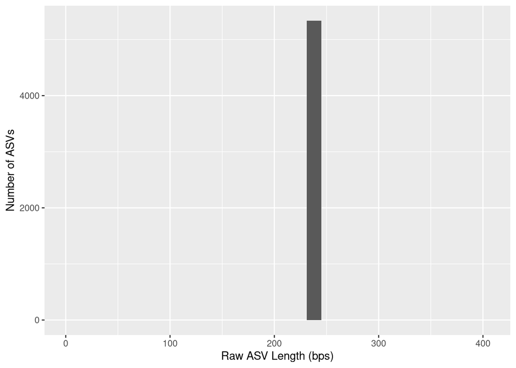

```r
# Inspect the distribution of sequence lengths of all ASVs in data set
# AFTER TRIM
plot_ASVLength_raw <-
  data.frame(Seq_Length = nchar(getSequences(raw_ASV_table))) %>%
  ggplot(aes(x = Seq_Length )) +
  geom_histogram() +
  # include the x-axis scales
  scale_x_continuous(limits = c(0, maxLength_ASV + 5)) +
  labs(y = "Number of ASVs", x = "Raw ASV Length (bps)")

# Show the plot
plot_ASVLength_raw
```

I am surprised that the ASV lengths are at around 237 because I used trunclen (240, 200) and I tought that eliminating 50 bp on the reverse meant that I was gonna get lengths of 200 as well. I am pretty pleased with the sequence length given that I was more focused on mantaining sequence depth. —– My sequences are mainly on the 237 and 245 bp but since in the 16s v4 region we dont expect much variation of length then I am choosing the 237 bp which has more ASVs, since 237-245 would be too big of a range with 2 peaks on opposite sides.

## What are the current ASV lengths?

```r
# Subset only ASVs that are 245 bps long
raw_ASV_table_trimmed <-
  raw_ASV_table[,nchar(colnames(raw_ASV_table)) == 237]

# Inspect the distribution of sequence lengths of all ASVs in dataset
table(nchar(getSequences(raw_ASV_table_trimmed)))
```

```
##
##  237
## 2658
```

```r
# What proportion of total ASV sequences are left in the data?
percRetained_Trimmed <- sum(raw_ASV_table_trimmed)/sum(raw_ASV_table)
percRetained_Trimmed # Show it
```

```
## [1] 0.368125
```

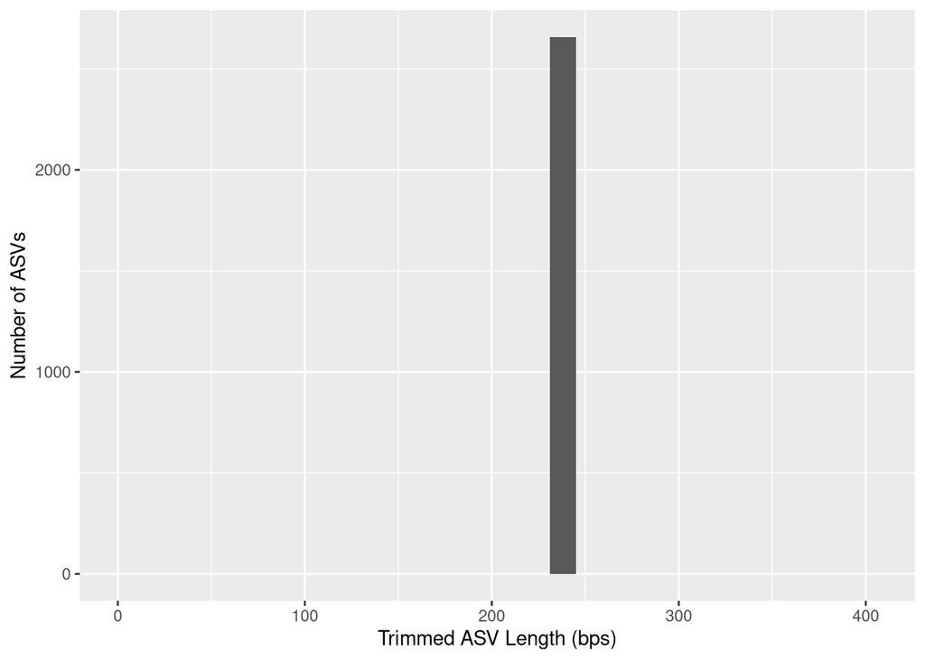

```r
# Inspect the distribution of sequence lengths of all ASVs in dataset
# AFTER TRIM
plot_ASVLength_trimmed <-
  data.frame(Seq_Length = nchar(getSequences(raw_ASV_table_trimmed))) %>%
  ggplot(aes(x = Seq_Length )) +
  geom_histogram() +
  # include the x-axis scales
  scale_x_continuous(limits = c(0, maxLength_ASV + 5)) +
  labs(y = "Number of ASVs", x = "Trimmed ASV Length (bps)")

# Show the plot
plot_ASVLength_trimmed
```

# Remove Chimeras

```r
# Remove the chimeras in the raw ASV table
noChimeras_ASV_table <-
  removeBimeraDenovo(raw_ASV_table_trimmed,
                     method="consensus",
                     multithread = n_threads,
                     verbose=TRUE)
```

```
## Identified 965 bimeras out of 2658 input sequences.
```

```r
# Check the dimensions
dim(noChimeras_ASV_table)
```

```
## [1]  367 1693
```

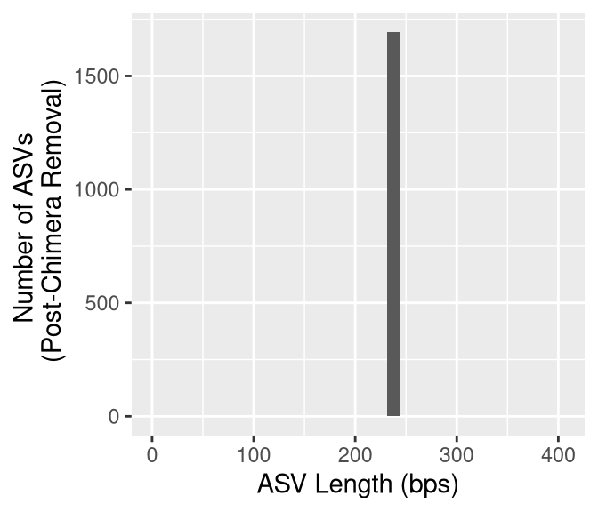

```r
# What proportion is left of the sequences?
# Chimera removal compared to trimming
percRetained_chimerasTrimmed <- sum(noChimeras_ASV_table)/sum(raw_ASV_table_trimmed)
# Chimera removal compared to raw
percRetained_chimerasRaw <-sum(noChimeras_ASV_table)/sum(raw_ASV_table)

# Plot it
plot_ASVLength_NoChimeras <-
  data.frame(Seq_Length_NoChim = nchar(getSequences(noChimeras_ASV_table))) %>%
  ggplot(aes(x = Seq_Length_NoChim )) +
  geom_histogram()+
  # include the x-axis scales
  scale_x_continuous(limits = c(0, maxLength_ASV + 5)) +
  labs(y = "Number of ASVs \n (Post-Chimera Removal)",
       x = "ASV Length (bps)")

# Show the plot
plot_ASVLength_NoChimeras
```

1. 36.81% of the raw ASVs were retained *after trimming*.
2. 98.09% of the trimmed ASV counts were retained *after chimera removal*.
3. This translates to 36.11% retention of the original, raw merged ASV counts after *both trimming and chimera removal.*

### Plot ASV Lengths

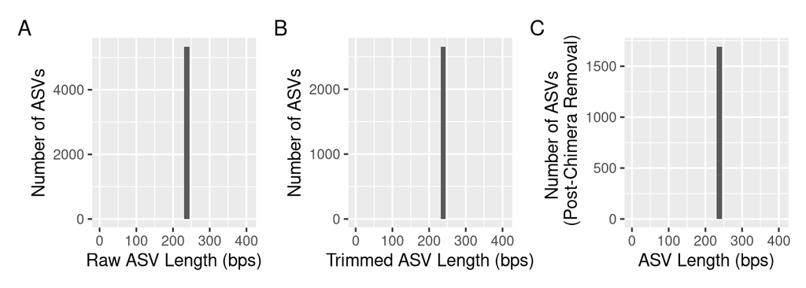

```r
plot_ASVLength_raw + plot_ASVLength_trimmed + plot_ASVLength_NoChimeras +
    plot_annotation(tag_levels = 'A')
```

# Track the read counts

```r
# A little function to identify number seqs
getN <- function(x) sum(getUniques(x))

# Make the table to track the seqs
track <- cbind(sapply(dada_forward, getN),
               sapply(dada_reverse, getN),
               sapply(merged_ASVs, getN),
               rowSums(noChimeras_ASV_table))

head(track)
```

```
##                                  [,1]  [,2]  [,3]  [,4]
## SRR6443836_R1_filtered.fastq.gz 22280 22346 22196 20480
## SRR6443837_R1_filtered.fastq.gz 10284 10364  9854     0
## SRR6443839_R1_filtered.fastq.gz 31258 31375 30538 27672
## SRR6443840_R1_filtered.fastq.gz 22961 22931 22752     0
## SRR6443844_R1_filtered.fastq.gz 11368 11412 11182 10497
## SRR6443845_R1_filtered.fastq.gz 17029 17023 16843     0
```

```r
# Update column names to be more informative (most are missing at the moment!)
colnames(track) <- c("denoisedF", "denoisedR", "merged", "nochim")
rownames(track) <- row.names(noChimeras_ASV_table)

# Generate a dataframe to track the reads through our DADA2 pipeline
track_counts_df <-
  track %>%
  # make it a dataframe
  as.data.frame() %>%
  rownames_to_column(var = "sample_names")

# Now let's add a column for the number of ASVs
# First, intuition check that the samples match
stopifnot(track_counts_df$sample_names == row.names(noChimeras_ASV_table))

# Now, let's add a new column with the number of ASVs
track_counts_df <-
  track_counts_df %>%
  mutate(num_ASVs = rowSums(noChimeras_ASV_table > 1))

# Visualize it in table format
DT::datatable(track_counts_df)
```

|  | sample_names | denoisedF | denoisedR | merged | nochim | num_ASVs |
| --- | --- | --- | --- | --- | --- | --- |
| 1 | SRR6443836_R1_filtered.fastq.gz | 22280 | 22346 | 22196 | 20480 | 107 |
| 2 | SRR6443837_R1_filtered.fastq.gz | 10284 | 10364 | 9854 | 0 | 0 |
| 3 | SRR6443839_R1_filtered.fastq.gz | 31258 | 31375 | 30538 | 27672 | 193 |
| 4 | SRR6443840_R1_filtered.fastq.gz | 22961 | 22931 | 22752 | 0 | 0 |
| 5 | SRR6443844_R1_filtered.fastq.gz | 11368 | 11412 | 11182 | 10497 | 114 |
| 6 | SRR6443845_R1_filtered.fastq.gz | 17029 | 17023 | 16843 | 0 | 0 |
| 7 | SRR6443852_R1_filtered.fastq.gz | 12059 | 12084 | 11808 | 0 | 0 |
| 8 | SRR6443863_R1_filtered.fastq.gz | 19735 | 19819 | 19444 | 0 | 0 |
| 9 | SRR6443869_R1_filtered.fastq.gz | 22868 | 22967 | 21846 | 0 | 0 |
| 10 | SRR6443871_R1_filtered.fastq.gz | 32443 | 32465 | 31701 | 29768 | 140 |

[output cut: 357 more lines]

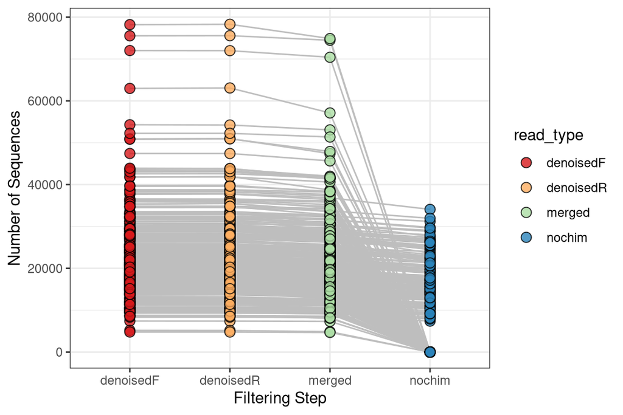

```r
# Plot it!
track_counts_df %>%
  pivot_longer(denoisedF:nochim, names_to = "read_type", values_to = "num_reads") %>%
  mutate(read_type = fct_relevel(read_type, "denoisedF", "denoisedR", "merged", "nochim")) %>%
  ggplot(aes(x = read_type, y = num_reads, fill = read_type)) +
  geom_line(aes(group = sample_names), color = "grey") +
  geom_point(shape = 21, size = 3, alpha = 0.8) +
  scale_fill_brewer(palette = "Spectral") +
  labs(x = "Filtering Step", y = "Number of Sequences") +
  theme_bw()
```

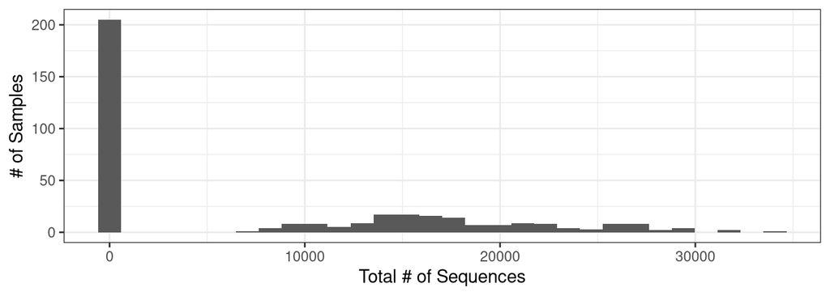

```r
plot_ReadDepth <-
  track_counts_df %>%
  ggplot(aes(x = nochim)) +
  geom_histogram() +
  labs(x = "Total # of Sequences", y = "# of Samples") +
  theme_bw()
plot_ReadDepth
```

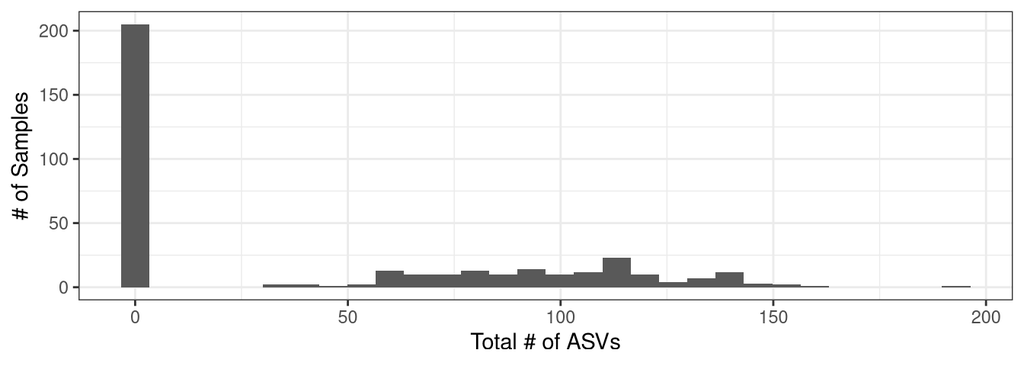

```r
# What is the ASV richness per sample?
plot_ASVRichness <-
  track_counts_df %>%
  ggplot(aes(x = num_ASVs)) +
  geom_histogram() +
  labs(x = "Total # of ASVs", y = "# of Samples") +
  theme_bw()
plot_ASVRichness
```

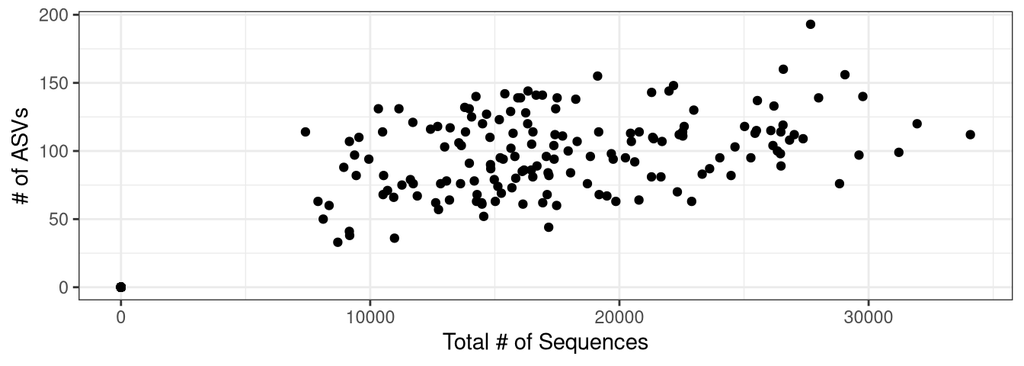

```r
# Now, let's look at the relationship of ASVs and Sequencing depth
plot_ReadDepth_ASVRichness <-
  track_counts_df %>%
  ggplot(aes(x = nochim, y = num_ASVs)) +
  geom_point() +
  labs(x = "Total # of Sequences", y = "# of ASVs") +
  theme_bw()
plot_ReadDepth_ASVRichness
```

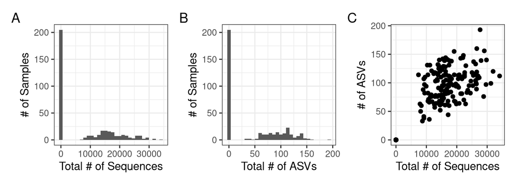

```r
# Show the plots together
plot_ReadDepth + plot_ASVRichness + plot_ReadDepth_ASVRichness +
    plot_annotation(tag_levels = 'A')
```

The first plot is a histogram that shows the distribution of sequences cross samples, most of the samples have very few sequences, a smaller subset has a lot of sequences, this could indicate low quality or over trimming. the second histogram detects the ASVs per sample, there is a similar trend to plot A, with some aditional information about the depth across samples. The third is a scatter plot that shows the relationship between sequence number and ASVs number per sample, there is a positive slope indicating that more sequences lead to more ASVs, the spread shows that different samples have different microbial diversity as expected.